# Project Analysis_jq2282

# 1. Data Exploration

## 1.1. Import data

```r
library(readxl)
data <- read_excel("~/Desktop/AdvancedDA/Project/NHANES Dataset Smoking.xlsx")
```

[output not shown]

[output not shown]

```r
View(data)
```

The National Health and Nutrition Survey (NHANES3.DAT) contains 17030 observations and 16 variables. (delete)SDPPSU6: Pseudo-PSU: 1, 2. (delete)SDPSTRA6: Pseudo-stratum: 01-49 (delete)WTPFHX6: Statistical weight: 225.93-139744.9 HSAGEIR: Age: years HSSEX: Sex: 0=Female, 1=Male DMARACER: Race: 1=White, 2=Black, 3=Other. BMPWTLBS: Body Weight: pounds BMPHTIN: Standing Height: inches (delete)PEPMNK1R: Average Systolic BP: mm Hg PEPMNK5R: Average Diastolic BP: mm Hg (delete)HAR1: Has repondent smoked > 100 cigarettes in life: 1=Yes, 2=No (delete)HAR3: Does respondent smoke cigarettes now: 1=Yes, 2=No SMOKE: Smoking: 1=if HAR1=2, 2=if HAR1=1&HAR3=2, 3=if HAR1=1&HAR3=1 TCP: Serum Cholesterol: mg/100 ml HBP: High Blood Pressure: 0 if PEPMNK1R <=140, 1 if PEPMNK1R > 140

```r
# data <- na.omit(data)
# barplot(table(data$HBP))
data<-data[-dim(data)[1],]
data<-data[,-c(1,2,3,11,13,14)]
data<-na.omit(data)
#View(data)
```

```r
colnames(data)
```

```
 [1] "SDPSTRA6" "WTPFHX6"  "HSAGEIR"  "HSSEX"    "DMARACER" "BMPWTLBS" "BMPHTIN"  "PEPMNK5R"
 [9] "SMOKE"    "TCP"      "HBP"
```

## 1.2. Split data into training and testing

```r
# Create training and Test samples
data_yes = data[data$HBP==1,]
data_no = data[data$HBP==0,]
cat('#records of HBP=1: ',nrow(data_yes), '. #records of HBP=0: ', nrow(data_no))
```

```
#records of HBP=1:  3250 . #records of HBP=0:  12393
```

```r
size = nrow(data_yes)
set.seed(100)
train_yes_id = sample(size, 0.9*size, replace=FALSE)
train_no_id = sample(nrow(data_no), 0.9*size, replace=FALSE)
train_yes = data_yes[train_yes_id,]
train_no = data_no[train_no_id,]
train_data = rbind(train_yes, train_no)
print(table(train_data$HBP))
```

```
   0    1
2925 2925
```

```r
test_yes = data_yes[-train_yes_id,]
test_no = data_no[-train_no_id,]
test_data = rbind(test_yes, test_no)
table(test_data$HBP)
```

```
   0    1
9468  325
```

```r
cor(train_data$PEPMNK1R, train_data$PEPMNK5R)
```

[output not shown]

```r
summary(glm(train_data$HBP~factor(train_data$SMOKE)+train_data$PEPMNK5R,family=binomial("logit")))
```

```
Call:
glm(formula = train_data$HBP ~ factor(train_data$SMOKE) + train_data$PEPMNK5R,
    family = binomial("logit"))

Deviance Residuals:
    Min       1Q   Median       3Q      Max
-2.1890  -1.0350  -0.0708   1.0350   3.0942

Coefficients:
                           Estimate Std. Error z value Pr(>|z|)
(Intercept)               -5.760599   0.223402 -25.786  < 2e-16 ***
factor(train_data$SMOKE)2  0.313331   0.067163   4.665 3.08e-06 ***
factor(train_data$SMOKE)3 -0.522395   0.072519  -7.204 5.86e-13 ***
train_data$PEPMNK5R        0.075221   0.002885  26.072  < 2e-16 ***
---
Signif. codes:  0 ‘***’ 0.001 ‘**’ 0.01 ‘*’ 0.05 ‘.’ 0.1 ‘ ’ 1

(Dispersion parameter for binomial family taken to be 1)

    Null deviance: 8109.8  on 5849  degrees of freedom
Residual deviance: 7135.0  on 5846  degrees of freedom
AIC: 7143

Number of Fisher Scoring iterations: 3
```

```r
table(train_data$SMOKE)
```

[output not shown]

## 1.3. Distribution plot

```r
library(RColorBrewer)
par(mfrow=c(1,3))
barplot(table(train_data$HSSEX), main="Barplot of Sex", names.arg = c("Female","Male"),col = brewer.pal(n = 2, name = "RdBu"))
```

```
minimal value for n is 3, returning requested palette with 3 different levels
```

```r
barplot(table(train_data$DMARACER), main="Barplot of Race",names.arg = c("White","Black","Other"),col = brewer.pal(n = 3, name = "RdBu"))
```

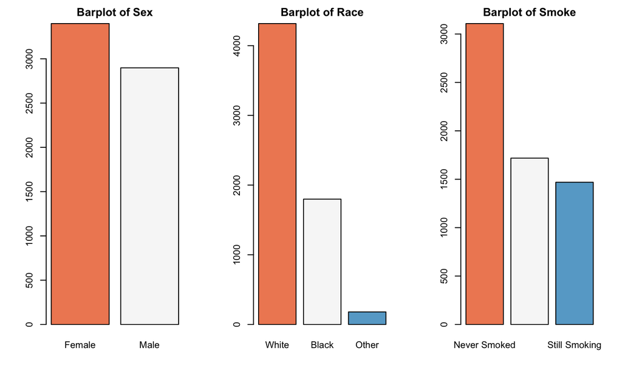

```r
barplot(table(train_data$SMOKE), main="Barplot of Smoke", names.arg = c("Never Smoked","Quit Smoking","Still Smoking"),col = brewer.pal(n = 3, name = "RdBu"))
```

```r
par(mfrow=c(2,2))
boxplot(train_data$HSAGEIR, main="Boxplot of Age",col = brewer.pal(n = 2, name = "RdBu"))
```

```
minimal value for n is 3, returning requested palette with 3 different levels
```

```r
boxplot(train_data$BMPWTLBS, main="Boxplot of Weight",col = brewer.pal(n = 2, name = "RdBu"))
```

```
minimal value for n is 3, returning requested palette with 3 different levels
```

```r
boxplot(train_data$BMPHTIN, main="Boxplot of Height",col = brewer.pal(n = 2, name = "RdBu"))
```

```
minimal value for n is 3, returning requested palette with 3 different levels
```

```
minimal value for n is 3, returning requested palette with 3 different levels
```

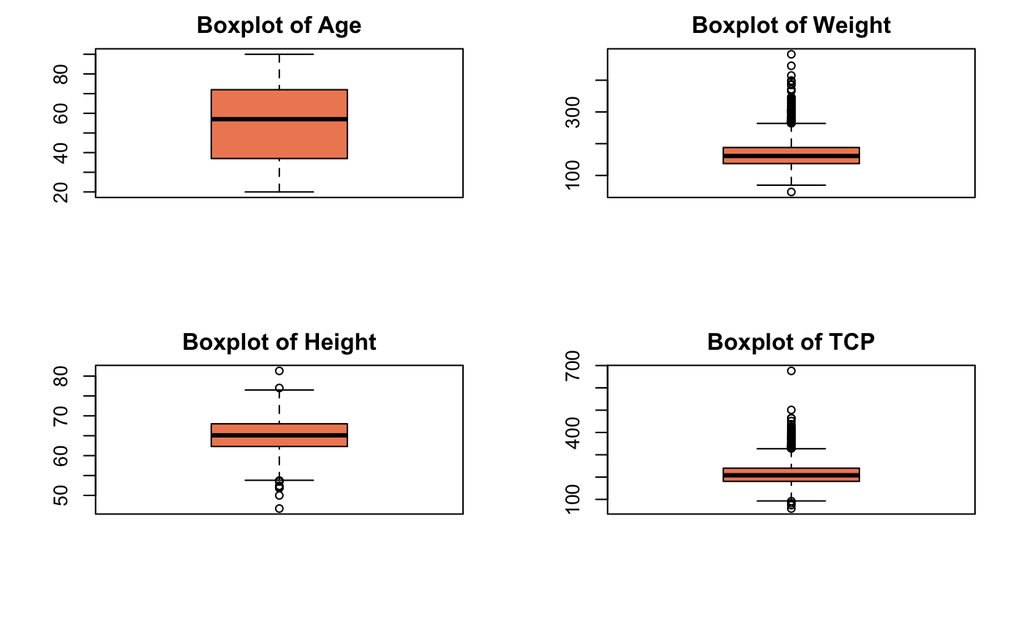

```r
boxplot(train_data$TCP, main="Boxplot of TCP",col = brewer.pal(n = 2, name = "RdBu"))
```